# ggplot part 2 assignment

Amanda Mae Woodward

2024-10-24

1. Open the starwars dataset (located in tidyverse)

```r
library(tidyverse)
data(starwars)
```

2. Create a scatter plot of character’s height and mass.

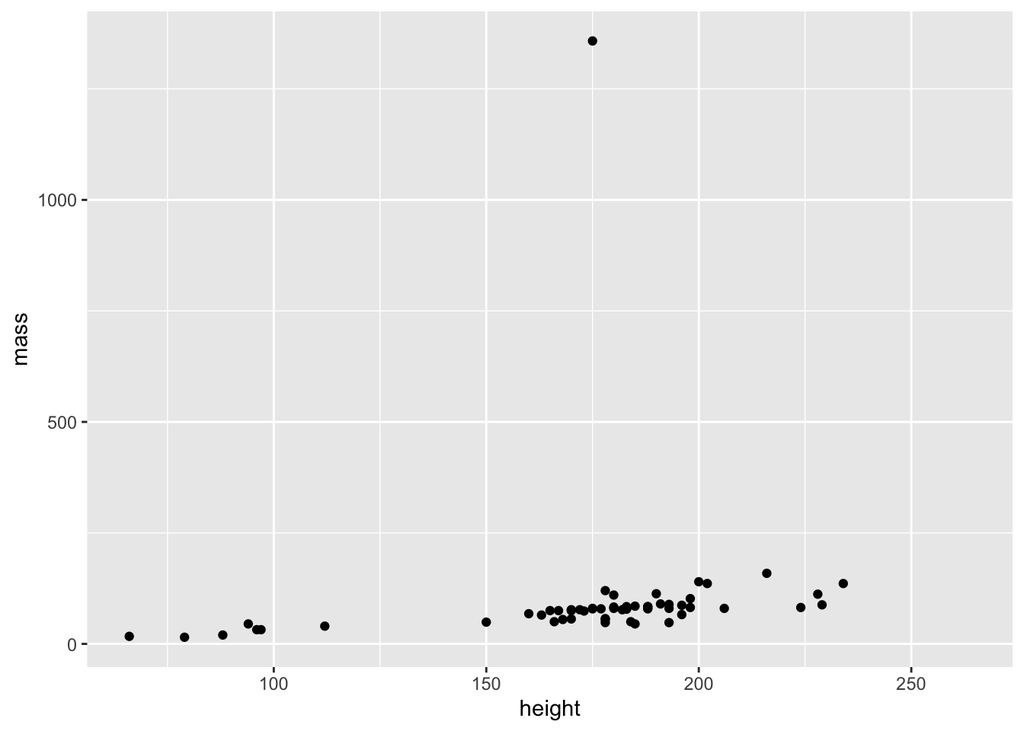

```r
ggplot(starwars, aes(height,mass)) +
  geom_point()
```

2a. Change the color and shape of the points in your scatter plot.

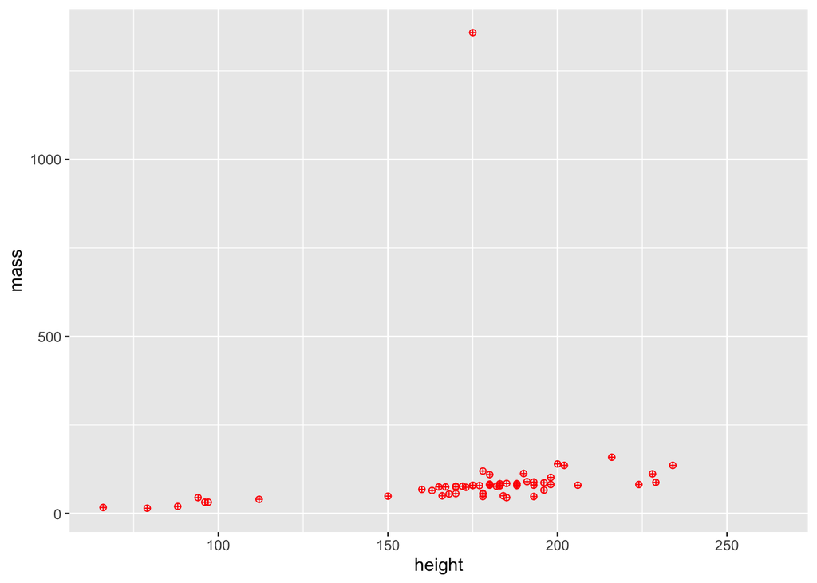

```r
ggplot(starwars, aes(height,mass)) +
  geom_point(shape = 10 , color = "red")
```

3. Add Homeworld as a third variable to your scatterplot.

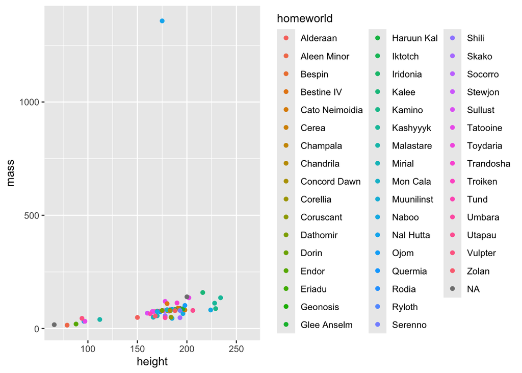

```r
ggplot(starwars, aes(x = height, y = mass, color = homeworld)) +
  geom_point()
```

3a. What do you notice about the graph? (e.g. describe what you see)

There are so many different homeworldss in the key that the graph itself is tiny in the preview window– extremely skinny! I would probably try to find a different way to present this data if it wasn’t for an assignment.

4. Make a boxplot of height.

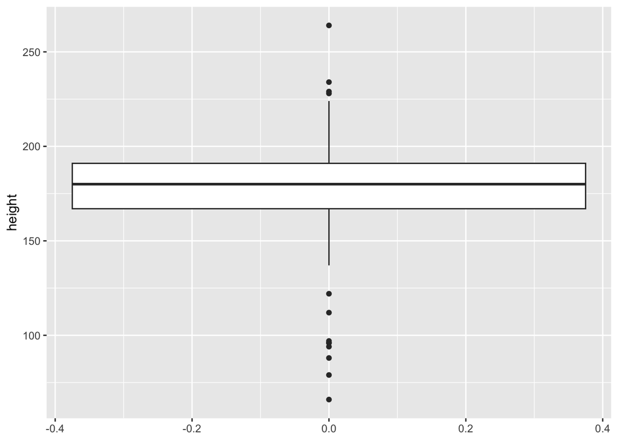

```r
ggplot(starwars, aes(,y = height)) +
  geom_boxplot()
```

5. Make a boxplot of height for each species present in the data.

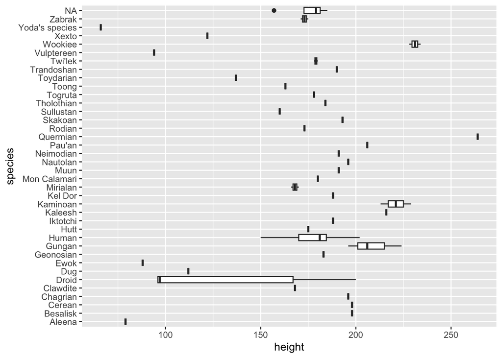

```r
ggplot(starwars, aes(height, species)) +
  geom_boxplot()
```

5a. change the appearance of your graph in at least 3 ways.

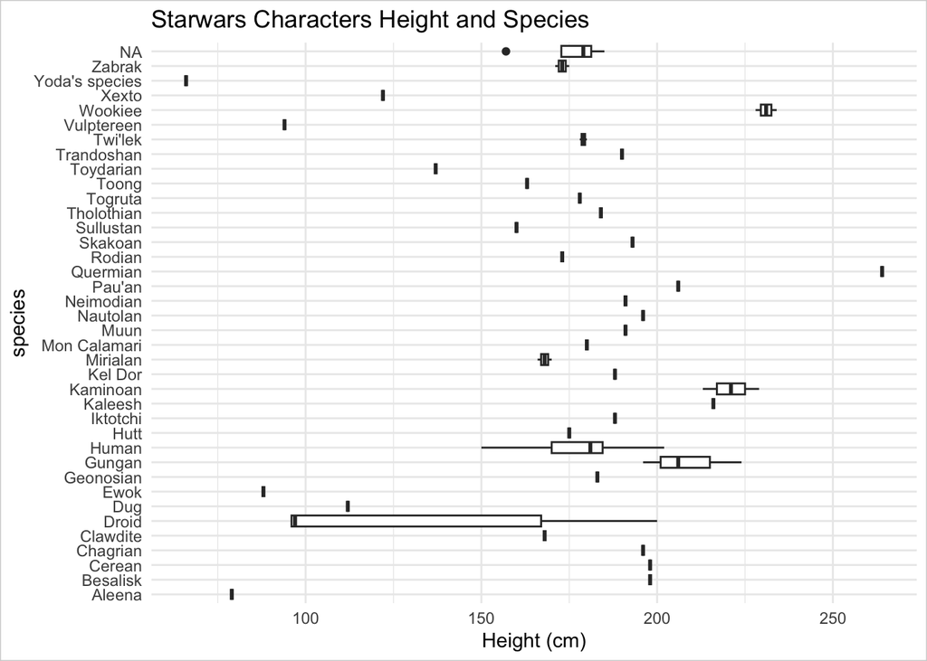

```r
ggplot(starwars, aes(height, species)) +
  geom_boxplot() +
  theme_minimal() +
  theme(
    plot.background = element_rect(colour = "lightgray"),
    axis.title.x = element_text(color = "black", hjust = .5)) +
  labs(
    x = "Height (cm)",
    title = "Starwars Characters Height and Species")
```

6. Using any variables in the starwars dataset, create a graph that uses a color palette from viridis.

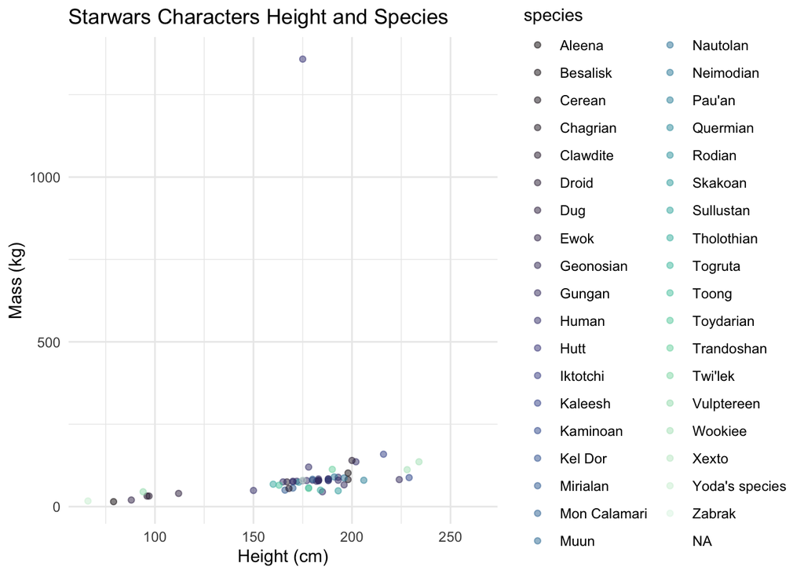

```r
ggplot(starwars, aes(height, mass, color = species)) +
  geom_point() +
  scale_color_viridis_d(alpha = 0.5, option = "G") +
  theme_minimal() +
  labs(
    x = "Height (cm)",
    title = "Starwars Characters Height and Species",
    y = "Mass (kg)")
```

7.Using any variables in the starwars dataset, create a graph that uses a color palette from RColorBrewer.

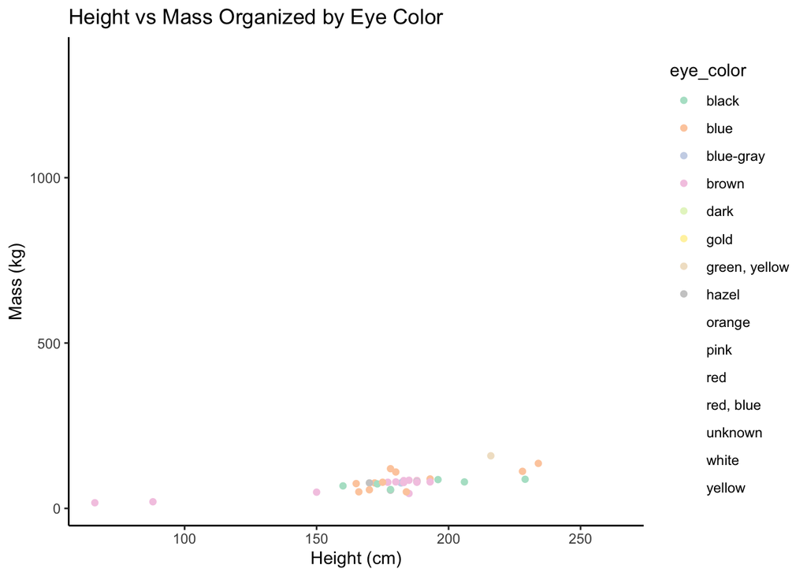

```r
library(RColorBrewer)
ggplot(starwars, aes(height, mass, color = eye_color)) +
  geom_point() +
  scale_color_brewer(palette = "Pastel2") +
  theme_classic() +
  labs(title = "Height vs Mass Organized by Eye Color",
       x = "Height (cm)",
       y = "Mass (kg)")
```

8. Using any variables in the starwars dataset, create a graph using facet_wrap

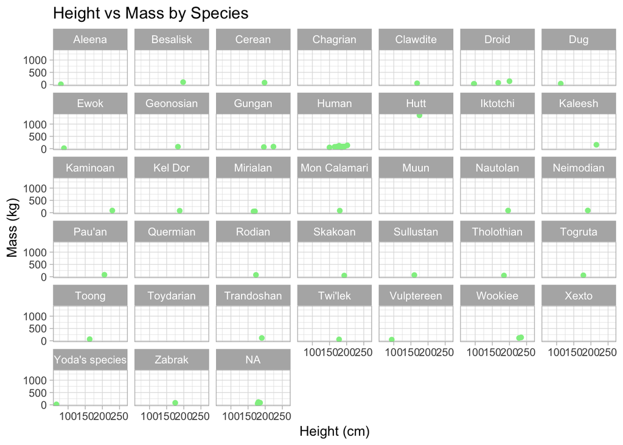

```r
ggplot(starwars, aes(height, mass)) +
  geom_point(color = "lightgreen") +
  facet_wrap(~ species) +
  theme_light() +
  labs(title = "Height vs Mass by Species",
       x = "Height (cm)",
       y = "Mass (kg)")
```